# Linear Regression

Krzysztof Mierzejewski

01-04-2018

# 1 Wczytanie i przygotowanie danych

## 1.1 Wczytanie zbioru danych z pliku płaskiego

```r
autodane<-read.table("/usr/miswdm/autodane.csv", header = TRUE, sep = ",", dec = ".")
```

| Cena | Wiek | Przebieg |
| --- | --- | --- |
| 12 | 10 | 180 |
| 22 | 6 | 65 |
| 15 | 8 | 120 |
| 35 | 4 | 50 |
| 21 | 8 | 150 |
| 25 | 7 | 70 |
| 28 | 5 | 100 |
| 33 | 6 | 70 |
| 36 | 3 | 50 |
| 43 | 1 | 15 |

## 1.2 Zmienne pomocnicze

```r
p<-2                # liczba predyktorów
no<-nrow(autodane)
indices<-seq(no)
df<-no-p-1          # liczba stopni swobody
```

## 1.3 Zmienne egzogeniczne

```r
wiek<-autodane$Wiek
przebieg<-autodane$Przebieg
```

## 1.4 Zmienna endogeniczna

```r
cena<-autodane$Cena
```

## 1.5 Nowa obserwacja

Do prognozowania ceny.

```r
new.car<-data.frame(wiek=4, przebieg=145)
```

# 2 Obliczanie kowariancji

Kowariancja – miara wielkości zależności liniowej pomiędzy zmiennymi losowymi: $\begin{aligned} Cov(X, Y)=\mathbb{E}[(X-\mathbb{E}[X])\cdot(Y-\mathbb{E}[Y])]=\mathbb{E}[XY]-\mathbb{E}[X]\cdot\mathbb{E}[Y] \end{aligned}$

## 2.1 Wariancja wieku

$\begin{aligned} Var(X)=\mathbb{E}[(X-\mathbb{E}[X])^2]=\mathbb{E}[X^2]-{\mathbb{E}[X]}^2 \end{aligned}$

Zgodny, nieobciążony estymator z próbki:  
$\begin{aligned} Var(X)=\frac{1}{n-1}\sum_{i=1}^n(x_i-\bar{x})^2 \end{aligned}$

```r
wiek.mean<-sum(wiek)/no
wiek.diff<-wiek-wiek.mean
wiek.diff.power<-wiek.diff^2
var.wiek<-sum(wiek.diff.power)/(no-1)
```

```
[1] 7.066667
```

## 2.2 Wariancja przebiegu

Zgodny, nieobciążony estymator z próbki.

```r
przebieg.mean<-sum(przebieg)/no
przebieg.diff<-przebieg-przebieg.mean
przebieg.diff.power<-przebieg.diff^2
var.przebieg<-sum(przebieg.diff.power)/(no-1)
```

```
[1] 2540
```

## 2.3 Kowariancja zmiennych egzogenicznych

Zgodny, nieobciążony estymator z próbki:  
$\begin{aligned} Cov(X, Y)=\frac{1}{n-1}\sum_{i=1}^n(x_i-\bar{x})\cdot(y_i-\bar{y}) \end{aligned}$

```r
x.mult<-wiek.diff*przebieg.diff
cov.x<-sum(x.mult)/(no-1)
```

```
[1] 119.8889
```

Obliczenia pomocnicze.

```r
cena.mean<-sum(cena)/no
cena.diff<-cena-cena.mean
wiek.cena.mult<-wiek.diff*cena.diff
przebieg.cena.mult<-przebieg.diff*cena.diff
```

Kowariancja wieku i ceny.

```r
cov.wiek.cena<-sum(wiek.cena.mult)/(no-1)
```

```
[1] -24.66667
```

Kowariancja przebiegu i ceny.

```r
cov.przebieg.cena<-sum(przebieg.cena.mult)/(no-1)
```

```
[1] -432.7778
```

# 3 Wyznaczanie wartości współczynników modelu

## 3.1 Macierz kowariancji zmiennych niezależnych

```r
A<-matrix(c(var.wiek, cov.x, cov.x, var.przebieg), nrow=p)
dimnames(A)<-list(c('wiek', 'przebieg'), c('wiek', 'przebieg'))
```

Alternatywnie.

```r
A<-cov(cbind(wiek, przebieg))
```

```
               wiek  przebieg
wiek       7.066667  119.8889
przebieg 119.888889 2540.0000
```

## 3.2 Wektor kowariancji wartości zmiennych niezależnych i zmiennych zależnych (obserwacji)

```r
B<-c(cov.wiek.cena, cov.przebieg.cena)
```

Alternatywnie.

```r
B<-cov(cbind(wiek, przebieg), cena)
```

```
[1]  -24.66667 -432.77778
```

## 3.3 Układ równań liniowych

7.0666667 * B<sub>1</sub> + 119.8888889 * B<sub>2</sub> = -24.6666667  
119.8888889 * B<sub>1</sub> + 2540 * B<sub>2</sub> = -432.7777778

Rozwiązanie układu.

```r
coef<-solve(A, B)
B1<-coef[1]; B2<-coef[2]
```

```
[1] "-3.01122024477396; -0.0282543025323229"
```

## 3.4 Wartość wyrazu wolnego B<sub>0</sub>

Obliczenia pomocnicze.

```r
aux<-B1*wiek+B2*przebieg
aux.numerator<-cena-aux
```

Wartość wyrazu wolnego B<sub>0</sub>.

```r
B0<-sum(aux.numerator)/no
```

Alternatywnie

```r
B0<-mean(cena-as.matrix(cbind(wiek, przebieg)) %*% coef)
```

```
[1] 46.9232
```

# 4 Model regresji liniowej

## 4.1 Funkcja prognozy wartości zmiennej zależnej

```r
est.fnc<-function(a, b) B0+B1*a+B2*b
```

Cena = 46.9232017 - 3.0112202 * Wiek - 0.0282543 * Przebieg

## 4.2 Prognozowana cena nowej obserwacji

```r
result<-est.fnc(new.car$wiek, new.car$przebieg)[[1]]
```

```
[1] 30.78145
```

## 4.3 Wariancja resztowa

Obliczenia pomocnicze.

```r
cena.est<-est.fnc(wiek, przebieg)
cena.est.diff<-cena-cena.est
cena.est.diff.power<-cena.est.diff^2
```

Suma kwadratów resztowych (suma kwadratów błędów).

```r
RSS<-sum(cena.est.diff.power)
```

```
[1] 93.4586
```

Nieobciążony estymator wariancji błędu obserwacji $\sigma^2$:  
$\begin{aligned} S^2=\frac{\sum_{i=1}^n(y_i-\hat{y_i})^2}{df}=\frac{\sum_{i=1}^n(y_i-\hat{y_i})^2}{n-k}=\frac{RSS}{n-p-1}={RSE}^2 \end{aligned}$  
$df$ - liczba stopni swobody  
$n$ - liczba obserwacji  
$k$ - liczba estymowanych parametrów; $k=p+1$

```r
S2<-RSS/df
```

```
[1] 13.35123
```

# 5 Dopasowanie modelu

## 5.1 Współczynnik R<sup>2</sup>

Całkowita suma kwadratów.

```r
cena.diff.power<-cena.diff^2
TSS<-sum(cena.diff.power)
```

```
[1] 872
```

$\begin{aligned} R^2=\frac{Regresyjna\ suma\ kwadratów}{Całkowita\ suma\ kwadratów} \end{aligned}$

```r
R2<-(TSS-RSS)/TSS
```

```
[1] 0.8928227
```

## 5.2 Współczynnik R<sup>2</sup> dopasowany

```r
R2.adj<-1-(1-R2)*(no-1)/df
```

```
[1] 0.8622006
```

## 5.3 Statystyka F

```r
F<-df*(TSS-RSS)/(p*RSS)
F.pValue<-pf(F, p, df, lower.tail=FALSE)
```

```
[1] 0.0004030507
```

## 5.4 Test t-Studenta

### 5.4.1 Macierz zmiennych niezależnych

Pierwszą kolumną jest wartość `1` dla wyznaczenia wartości błędu parametru wyrazu wolnego.

```r
X<-as.matrix(cbind(rep(1, no), wiek, przebieg))
```

### 5.4.2 Estymator macierzy kowariancji estymatora metody najmniejszych kwadratów

Macierz kowariancji parametrów modelu.

```r
Sigma<-S2*solve(t(X)%*%X)  #to samo co Sigma<-S2*solve(t(X)%*%X, diag(2))
colnames(Sigma)[1]<-rownames(Sigma)[1]<-'Intercept'
```

### 5.4.3 Błędy współczynników

Błąd współczynnika B<sub>0</sub>.

```r
B0.err<-sqrt(diag(Sigma)['Intercept'])  # to samo co B0.err<-sqrt(Sigma[1,1])
```

```
Intercept
 2.962759
```

Błąd współczynnika B<sub>1</sub>.

```r
B1.err<-sqrt(diag(Sigma)['wiek'])       # to samo co B1.err<-sqrt(Sigma[2,2])
```

```
    wiek
1.026498
```

Błąd współczynnika B<sub>2</sub>.

```r
B2.err<-sqrt(diag(Sigma)['przebieg'])   # to samo co B2.err<-sqrt(Sigma[3,3])
```

```
  przebieg
0.05414379
```

### 5.4.4 Wartości statystyki **t**

Dla współczynników B<sub>0</sub>, B<sub>1</sub>, B<sub>2</sub>.

```r
B0.t<-B0/B0.err
B1.t<-B1/B1.err
B2.t<-B2/B2.err
```

```
[1] "Intercept: 15.8376706620683; wiek: -2.93348798741743; przebieg: -0.521838285707935"
```

**H<sub>0</sub>**: *nie ma zależności pomiędzy predyktorem a zmienną objaśnianą; B<sub>i</sub> = 0*.  
Przyjęty poziom istotności: **5%**.

```r
alpha<-1-.05/2                          # test obustronny
tValue<-qt(alpha, df, lower.tail=TRUE)  # kwatyl rozkładu t-Studenta
```

Moduł wartości brzegowej obszaru krytycznego wynosi zatem:

```
[1] 2.364624
```

**p-wartości**

[output not shown]

## 5.5 Przedziały ufności współczynników modelu

Poziom ufności ciągle **95%**.

```r
tValues<-qt(c(1-alpha, alpha), df)
B0.conf<-B0+B0.err*tValues
B1.conf<-B1+B1.err*tValues
B2.conf<-B2+B2.err*tValues
```

```
Intercept: [39.917389890249; 53.929013589753]
wiek: [-5.43850286812919; -0.583937621418716]
przebieg: [-0.156284021335215; 0.099775416270569]
```

## 5.6 Przedział ufności wyestymowanych wartości modelu

Poziom istotności **5%**

```r
cena.est.conf<-data.frame(cena.est)
for (i in indices) {
  C<-c(1, wiek[i], przebieg[i])
  delta<-sqrt(drop(t(C)%*%Sigma%*%C))
  interval<-cena.est[i]+tValues*delta
  cena.est.conf$lwr[i]<-interval[1]
  cena.est.conf$upr[i]<-interval[2]
}
```

| cena.est | lwr | upr |
| --- | --- | --- |
| 11.72522 | 5.731752 | 17.71870 |
| 27.01935 | 22.767096 | 31.27161 |
| 19.44292 | 15.775111 | 23.11074 |
| 33.46561 | 30.008315 | 36.92290 |
| 18.59529 | 13.701139 | 23.48945 |
| 23.86686 | 18.207126 | 29.52659 |
| 29.04167 | 24.593028 | 33.49031 |
| 26.87808 | 23.092696 | 30.66346 |
| 36.47683 | 32.178454 | 40.77520 |
| 43.48817 | 37.490825 | 49.48551 |

# 6 Prognoza punktowa i błąd ex-ante

## 6.1 Wariancja prognozy

$\begin{aligned} S^2_\tau=S^2+S^2\cdot\left(\frac{1}{n}+\frac{(x_\tau-\bar{x})^2}{\sum_{i=1}^n(x_i-\bar{x})^2}\right)= \end{aligned}\\ \begin{aligned} =S^2\cdot\left(1+\frac{1}{n}+\frac{(x_\tau-\bar{x})^2}{\sum_{i=1}^n(x_i-\bar{x})^2}\right)= \end{aligned}\\ \begin{aligned} =S^2\cdot\left(1+\frac{\sum_{i=1}^nx_i^2+nx_\tau^2-2x_\tau\sum_{i=1}^nx_i}{n\sum_{i=1}^nx_i^2-(\sum_{i=1}^nx_i)^2}\right) \end{aligned}$  
$\hat{\Sigma}$ - estymator macierzy kowariancji estymatora metody najmniejszych kwadratów  
$C$ - wektor wartości nowej obserwacji (do kombinacji liniowej z modelem regresji)  
Standardowy błąd obserwacji:  
$\begin{aligned} \delta_\tau=S\sqrt{\frac{1}{n}+\frac{(x_\tau-\bar{x})^2}{\sum_{i=1}^n(x_i-\bar{x})^2}}=\sqrt{C^T\hat{\Sigma}C}=\sqrt{\delta_\tau^2} \end{aligned}$

```r
C<-c(1, new.car$wiek, new.car$przebieg)
est.var<-drop(t(C)%*%Sigma%*%C)          # to samo co est.var<-drop(C%*%Sigma%*%C)
```

```
[1] 24.9955
```

## 6.2 Błąd ex-ante

Błąd prognozy punktowej:  
$\begin{aligned} S_\tau=\sqrt{S^2+\delta_\tau^2}=\sqrt{S^2+C^T\hat{\Sigma}C} \end{aligned}$

```r
exAnte<-sqrt(S2+est.var)
```

```
[1] 6.192473
```

## 6.3 Względny błąd ex-ante

Względny błąd prognozy punktowej:  
$\begin{aligned} \eta_\tau=\frac{S_\tau}{|\hat{y_\tau}|}\cdot100\% \end{aligned}$

```r
exAnte.rel<-exAnte/abs(est.fnc(C[2], C[3]))
```

```
     wiek
0.2011755
```

## 6.4 Przedział ufności prognozy

```r
result.conf<-result+exAnte*tValues
```

```
[1] 16.13857 45.42432
```

# 7 Wykorzystanie pakietu `stats`

Funkcja `lm` z pakietu `stats` (będąca przeciążeniem funkcji `glm` z tego samego pakietu) pozwala na stworzenie modelu regresji liniowej z zastosowaniem *formuł*.

```r
est<-lm(cena~wiek+przebieg)
```

Współczynniki modelu.

```r
est$coefficients  #to samo co coefficients(est)
```

```
(Intercept)        wiek    przebieg
 46.9232017  -3.0112202  -0.0282543
```

Podsumowanie modelu.

```r
summary(est)
```

```
Call:
lm(formula = cena ~ wiek + przebieg)

Residuals:
    Min      1Q  Median      3Q     Max
-5.0194 -0.9033 -0.1010  1.4341  6.1219

Coefficients:
            Estimate Std. Error t value Pr(>|t|)
(Intercept) 46.92320    2.96276  15.838  9.7e-07 ***
wiek        -3.01122    1.02650  -2.933   0.0219 *
przebieg    -0.02825    0.05414  -0.522   0.6179
---
Signif. codes:  0 ‘***’ 0.001 ‘**’ 0.01 ‘*’ 0.05 ‘.’ 0.1 ‘ ’ 1

Residual standard error: 3.654 on 7 degrees of freedom
Multiple R-squared:  0.8928,    Adjusted R-squared:  0.8622
F-statistic: 29.16 on 2 and 7 DF,  p-value: 0.0004031
```

Przedziały ufności współczynników modelu (ang. *confidence intervals*).

```r
confint(est)
```

```
                2.5 %      97.5 %
(Intercept) 39.917390 53.92901359
wiek        -5.438503 -0.58393762
przebieg    -0.156284  0.09977542
```

Przedziały ufności wyestymowanych wartości modelu (ang. *narrow intervals*).

```r
predict(est, interval="confidence", level=.95)
```

```
        fit       lwr      upr
1  11.72522  5.731752 17.71870
2  27.01935 22.767096 31.27161
3  19.44292 15.775111 23.11074
4  33.46561 30.008315 36.92290
5  18.59529 13.701139 23.48945
6  23.86686 18.207126 29.52659
7  29.04167 24.593028 33.49031
8  26.87808 23.092696 30.66346
9  36.47683 32.178454 40.77520
10 43.48817 37.490825 49.48551
```

Predykcja z zadanym poziomem tolerancji (ang. *wide intervals*).

```r
pred<-predict(est, newdata=new.car, se.fit=TRUE, level=.95, interval="prediction")  # błąd.obserwacji=TRUE
```

```
$fit
       fit      lwr      upr
1 30.78145 16.13857 45.42432

$se.fit
[1] 4.99955

$df
[1] 7

$residual.scale
[1] 3.653933
```

Błąd ex-ante (wariancja modelu + wariancja obserwacji).

```r
signif(sqrt(pred$residual.scale^2+pred$se.fit**2), 4)
```

```
[1] 6.192
```

# 8 Zmienne skorelowane

```r
summary(lm(cena~wiek*przebieg))
```

Alternatywnie.

```r
summary(lm(cena~wiek+przebieg+wiek:przebieg))
```

```
Call:
lm(formula = cena ~ wiek * przebieg)

Residuals:
    Min      1Q  Median      3Q     Max
-5.0207 -0.9115 -0.0935  1.4333  6.1194

Coefficients:
                Estimate Std. Error t value Pr(>|t|)
(Intercept)   46.9001050  4.9745134   9.428  8.1e-05 ***
wiek          -3.0095093  1.1440731  -2.631    0.039 *
przebieg      -0.0276481  0.1158114  -0.239    0.819
wiek:przebieg -0.0000646  0.0106521  -0.006    0.995
---
Signif. codes:  0 ‘***’ 0.001 ‘**’ 0.01 ‘*’ 0.05 ‘.’ 0.1 ‘ ’ 1

Residual standard error: 3.947 on 6 degrees of freedom
Multiple R-squared:  0.8928,    Adjusted R-squared:  0.8392
F-statistic: 16.66 on 3 and 6 DF,  p-value: 0.002582
```

# 9 Wizualizacja

```r
library(scatterplot3d)
s3d<-scatterplot3d(x=wiek, y=przebieg, z=cena, angle=55, highlight.3d=T, scale.y=0.8)
s3d$plane3d(est)
residual3d<-function(x, y, z, residual){
  s3d$points3d(x=x, y=y, z=z-residual, type='p', lwd=1, pch=5, col=3)
  s3d$points3d(x=c(x, x), y=c(y, y), z=c(z-residual, z), type='l', lwd=1, col='dark green')
}
for (i in indices) {
  residual3d(wiek[i], przebieg[i], cena[i], est$residuals[i])
}
# Predykcja z zadanym poziomem tolerancji (ang. wide intervals).
s3d$points3d(x=new.car$wiek, y=new.car$przebieg, z=pred$fit[,'fit'], lwd=1, pch=21, bg=8, col=2)
s3d$points3d(x=rep(new.car$wiek, 2), y=rep(new.car$przebieg, 2), z=pred$fit[,2:3], lwd=1, type='l', col=2)
```

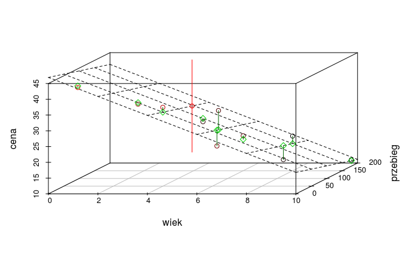

## 9.1 Przedziały ufności (osobny przykład)

```r
x<-1:7
y<-c(8, 13, 14, 17, 18, 20, 22)
est<-lm(y~x)
```

[output not shown]

Przedziały ufności.

```r
confint(est)  # to samo co confint(est, level=.95))
```

```
               2.5 %   97.5 %
(Intercept) 5.164838 9.692304
x           1.636671 2.649043
```

t-statystyka, stopni swobody: 5.

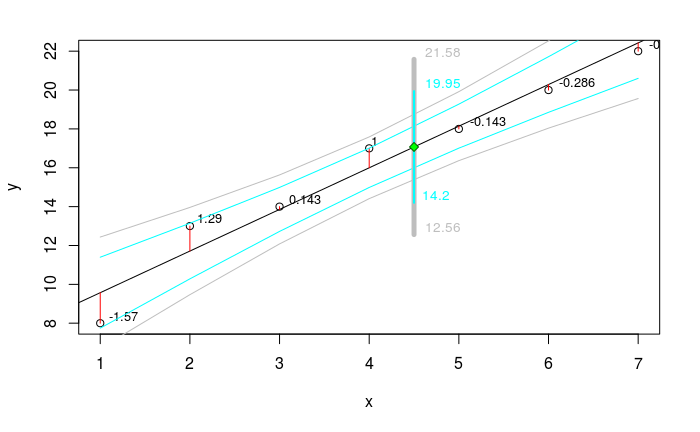

```r
res<-signif(residuals(est), 3)
pre<-predict(est, level=.99, interval="confidence")
plot(x, y)
abline(est)
segments(x, y, x, pre[,"fit"], col="red")
library(MASS)
library(calibrate)
textxy(x, y, res, cex=0.8)
# Przedziały ufności (ang. narrow intervals)
# 99%
lines(x, pre[,2], col=8)
lines(x, pre[,3], col=8)
# 95%
pre<-predict(est, level=0.95, interval="confidence")
lines(est$model[["x"]], pre[,2], col=5)
lines(est$model[["x"]], pre[,3], col=5)
# Predykcja z zadanym poziomem tolerancji (ang. wide intervals)
# 99%
result<-predict(est, newdata=data.frame(x=c(4.5)), level=.99, interval="prediction")
segments(4.5, result[,"lwr"], 4.5, result[,"upr"], col=8, lwd=5)
textxy(4.5, result[,"lwr"], round(result[,"lwr"], 2), cex=0.85, col=8)
textxy(4.5, result[,"upr"], round(result[,"upr"], 2), cex=0.85, col=8)
# 95%
result<-predict(est, newdata=data.frame(x=c(4.5)), level=.95, interval="prediction")
segments(4.5, result[,"lwr"], 4.5, result[,"upr"], col=5, lwd=2)
textxy(4.5, result[,"lwr"], round(result[,"lwr"], 2), cex=0.85, col=5)
textxy(4.5, result[,"upr"], round(result[,"upr"], 2), cex=0.85, col=5)
points(4.5, result[,"fit"], pch=23, col="darkgreen", bg="green")
```